# readme

# Visualizing COVID-19

Authors: Alex Cory, Dakota Rossi, Daniel Solomon

## Abstract

We want to create visualizations of COVID-19 to find correlations and patterns. We created several visualizations displaying Maryland’s COVID-19 data based on several factors including race, gender, and age. We found that older individuals tended to have more deaths and die at a much higher proportion than younger age groups. We noticed that there were very few deaths total under the age of about 40. We also found that white and African American individuals died at the highest rate in the state. Another finding of ours was that despite women being more likely to contract COVID-19, more men died from COVID than women.

# Introduction

By creating visualizations and exploring COVID data, we can grow our knowledge about viruses and help to figure out what demographics are most at-risk for illnesses like COVID-19. We also want to try to find patterns in the spread of COVID to see if certain events are likely to cause spikes in cases. Finally, we want to investigate COVID-19 deaths and see if those who catch COVID the most are also the ones dying the most from COVID, or if there are other factors in COVID death rates. In the `[Age]` section of the report, we investigate COVID cases and deaths, including how age impacts likelihood of catching or dying from COVID. In the `[Race]` section, we look at how race impacts COVID case and death rates. Finally, in the `[Gender]` section, we will investigate the differences in male and female COVID-19 statistics. Finally, we will conclude with some overall takeaways and limitations we found while analyzing our dataset.

```r
library(zoo)
library(tidyverse)
library(lubridate)
library(dplyr)
library(data.table)
df <- fread('MD_COVID-19_-_MASTER_Case_Tracker.csv')
df1 <- df %>% dplyr::mutate(year = year(as.Date(df$ReportDate,format="%m/%d/%Y")),
                 month = lubridate::month(as.Date(df$ReportDate,format="%m/%d/%Y")),
                 day = lubridate::day(as.Date(df$ReportDate,format="%m/%d/%Y")),
                 date = my(format(as.Date(df$ReportDate,format = "%m/%d/%Y"),"%m/%y")))
```

# Quick Data Summary

In this report, we will be looking at COVID cases and deaths, while relating them age, race, and gender demographics. Below are summaries of the COVID case and death delta data, as well as descriptions of the demographic categories we chose.

```r
summary(df1$CaseDelta)
```

```
##    Min. 1st Qu.  Median    Mean 3rd Qu.    Max.
##       0     509     854    1283    1364   17872
```

```r
summary(df1$deathsDelta)
```

```
##    Min. 1st Qu.  Median    Mean 3rd Qu.    Max.    NA's
##   -4.00    5.00   10.00   15.42   20.00   85.00      65
```

```r
colnames(df1[,47:55])
```

```
## [1] "case0to9"   "case10to19" "case20to29" "case30to39" "case40to49"
## [6] "case50to59" "case60to69" "case70to79" "case80plus"
```

These are the ranges of the age demographics. There are also variables with death information following a similar naming format. The number represent the ages of people within each of these ranges.

```r
colnames(df1[,60:65])
```

```
## [1] "caseAfrAmer"  "caseWhite"    "caseHispanic" "caseAsian"    "caseOther"
## [6] "caseNotAVail"
```

These are the race demographics specified by our dataset. The variables represent the number of cases from African American, White, Hispanic, and Asian individuals, with separate categories for “Other” and “Not Available” data. There are similar variables with similar names for death data within these demographics.

```r
colnames(df1[,57:58])
```

```
## [1] "genMale"   "genFemale"
```

These are the gender demographics that we used, with these variables referring to the amount of COVID cases from each gender. There is also a ‘genUnkn’ variable we did not use in our analysis. Once again, similar variables exist for death data as well.

# Results

## Age

Here, we will investigate how the age variable relates to COVID cases and deaths overtime. We can see in our total-cases-by-age figures how COVID cases have been increasing overtime across all age groups. In the prop-cases-by-age figures, we see an increase in the proportion of cases in young people, and a subsequent decrease in the proportion of COVID-19 cases among older demographics. In the figure total-deaths-by-age, we see how older individuals die from COVID at higher rates despite having fewer overall cases. Finally, our prop-deaths-by-age figure displays how much faster older demographics are passing away from COVID-19 when compared to younger individuals.

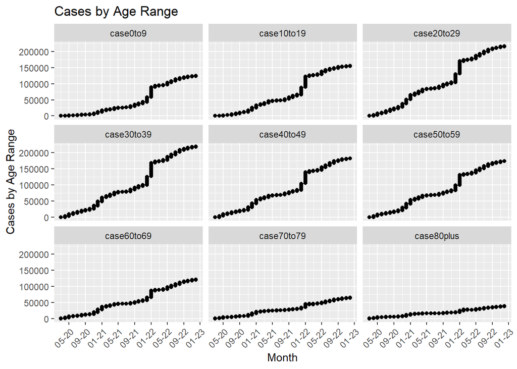

These figures show the total amount of COVID cases by age group, each of which showing a positive correlation. The demographics of people aged 20to29 and 30to39 feature the largest amount of COVID cases. There are more rapid increases towards late 2021 compared to other stretches of time.

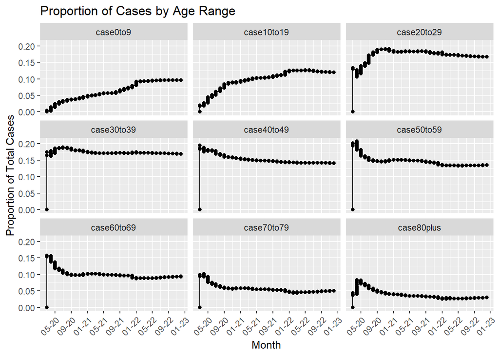

These figures show the proportion of COVID cases each age-range holds at a given time. The proportion of cases from younger people has increased over time, with all age ranges above 40 showing a decrease in proportion of COVID-cases since mid-2020. Cases among people aged 50to59 and 60to69 seem to have shown the greatest decrease in proportion of cases.

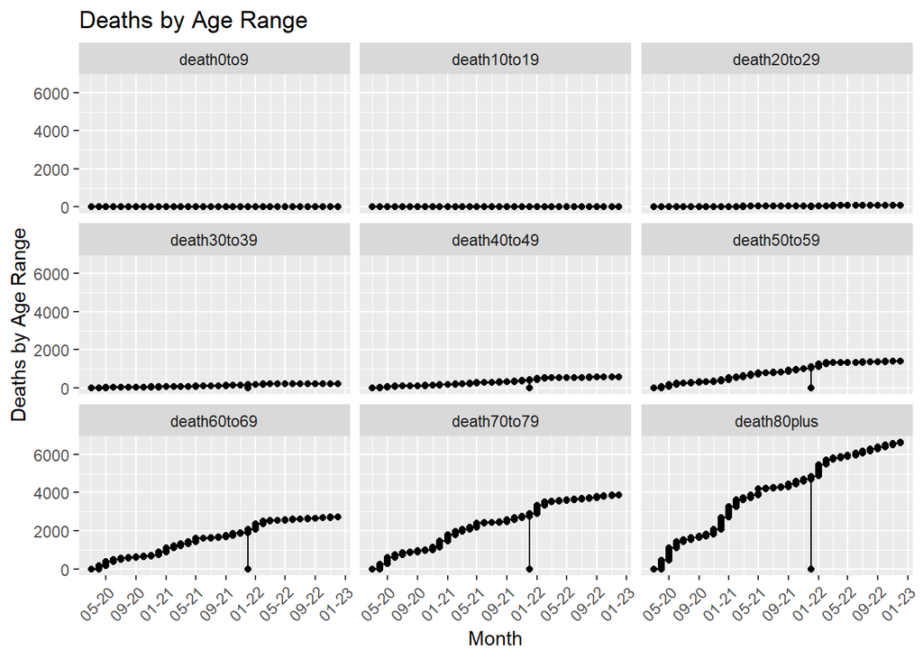

These figures show the total amount of COVID deaths by age-range, each of which increasing overtime. Older age ranges tend to make up far more COVID deaths than younger age ranges. There are outliers in the scatterplot for all age ranges towards the end of 2021, these are reflective of an issue present in the dataset and can be ignored.

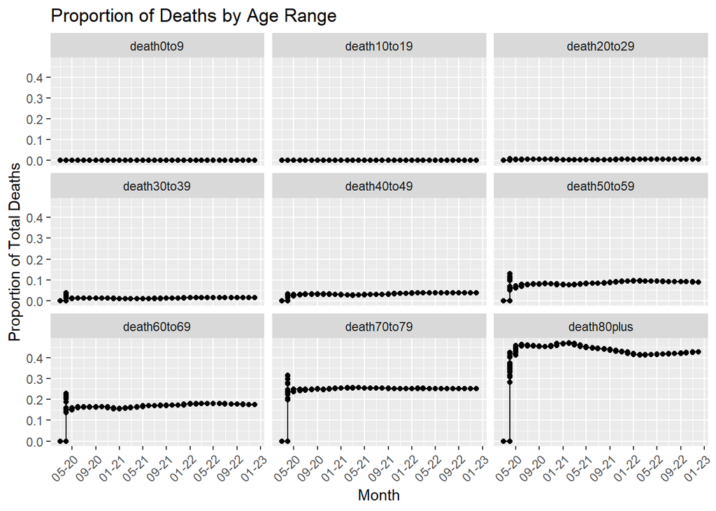

These figures show the proportion of COVID-19 deaths by age range, with all figures staying relatively static overtime. There are very few deaths in people aged 0 to 49, with people in the 80plus category holding the plurality of deaths. Less than 5% of deaths are shared by each age range prior to the 50to59 category.

## Race

In this section, we will investigate how the race of individuals in Maryland correlates with COVID data. We can see in our total-cases-by-race figures how COVID cases have been increasing overtime across all race demographics. In the prop-cases-by-race figure, we see a significant increase in the proportion of COVID cases among white Marylanders overtime. In total-deaths-by-race, we see the amount of COVID deaths overtime, which follow a similar trend to the case figures. Finally, our prop-deaths-by-age figure displays the proportion of total COVID deaths each demographic has shared, again showing an increase overtime for white Marylanders.

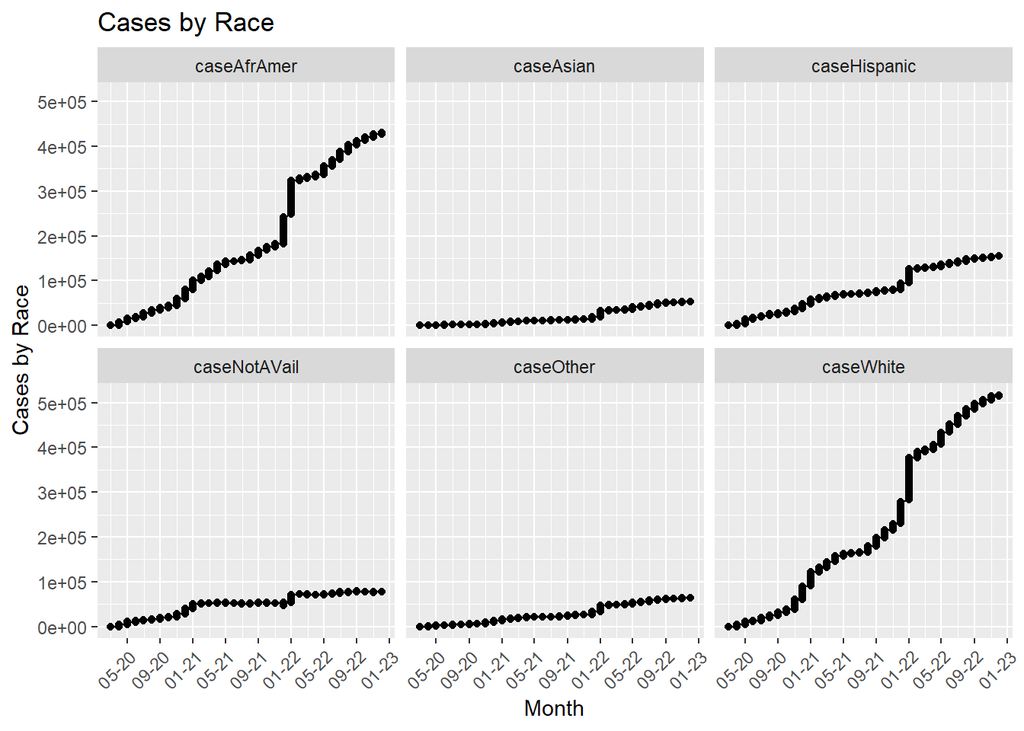

These figures show the amount of COVID cases across each race demographic, featuring large totals among African American and White individuals. Asian, Hispanic, and the other categories are dwarfed by the rapid increase in cases from African American and white Marylanders. There are sharp increases towards the end of 2021.

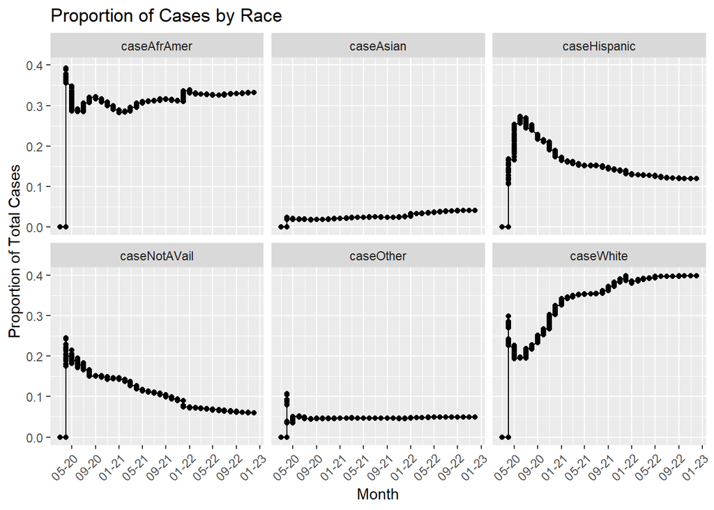

These figures show the proportion each race demographic holds of total COVID cases, showing White and African American individuals holding the vast majority of cases. Hispanic individuals have seen a large decrease in proportion of COVID cases since 2020, while white individuals have seen a large increase in proportion of cases. Cases with unavaliable race data has also decresed overtime, indicating better race identification metrics.

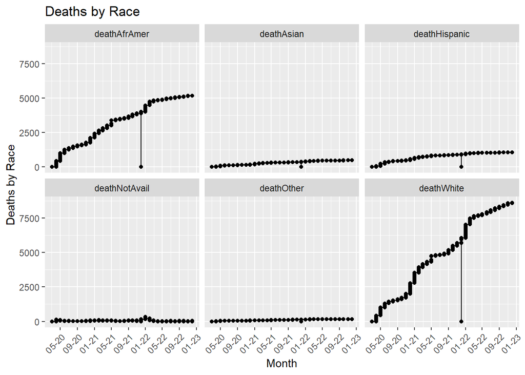

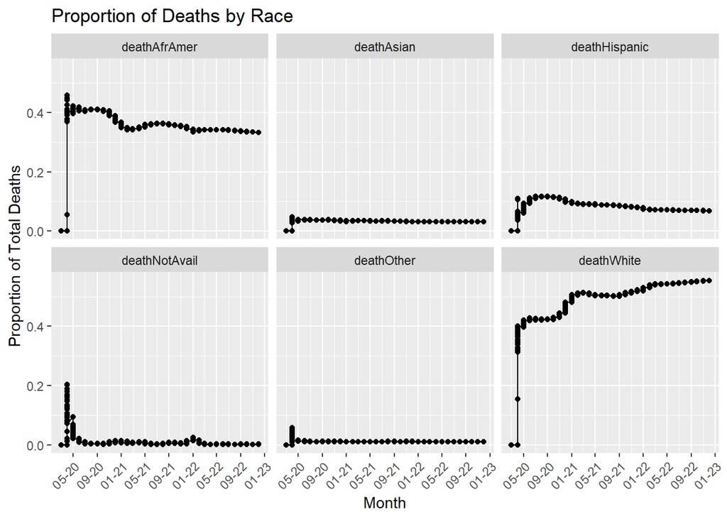

These figures display the proportion of total COVID deaths shared among each race demographic, with African American and White Marylanders holding the majority of deaths. Proportionally, white COVID deaths have increased overtime, while all other demographics have subsiquently decreased overtime.

## Gender

In this section, we will observe how gender and COVID data are correlated. First, in the total-cases-by-gender section, we see how women lead men in the total amount of COVID cases reported. We also see in the total-deaths-by-gender how men have died more than women from COVID. This is very interesting, as our initial expectation was for the gender with the most COVID cases to also have the most COVID deaths.

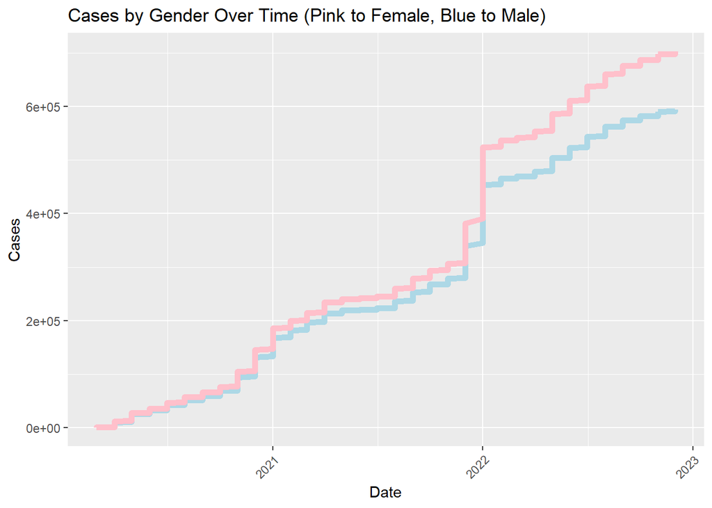

This chart displays the difference in male and female COVID cases, showing how women tend to get COVID at a higher rate than men. Women have consistently outpaced men in terms of total COVID case count. There are sharp spikes around the 2021 holiday season.

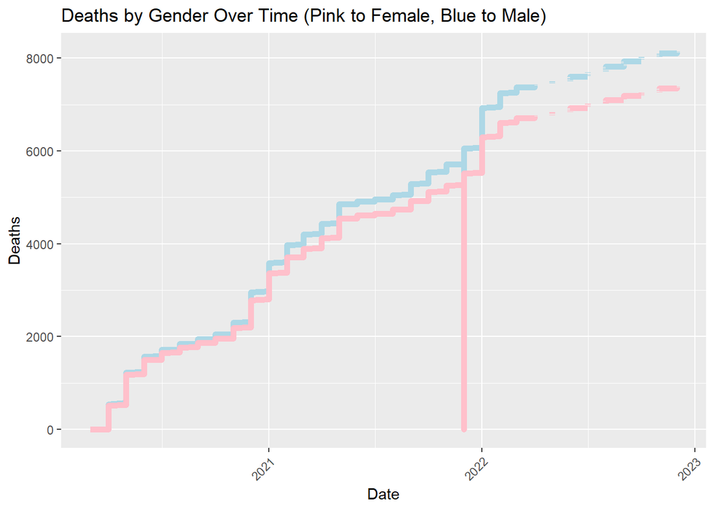

This chart shows the differnece in male and female COVID deaths overtime, displaying how men have died from COVID at a higher rate than women. This is interesting, as despite having COVID less frequently than women, men have outpaced women in terms of total COVID death count. There is a blip towards the end of 2021, this is indicative of a flaw in our dataset and can be ignored.

…

# Conclusions

From our data, we can see how COVID impacts different demographics in different ways. First, in the `[Age]` section, we saw how COVID cases are spread widely between age ranges, yet the majority of deaths come from older demographics. We also saw an increase in the proportion of total cases for the younger demographics in our dataset. Next, we took a look at race data in the `[Race]` section, and we found that white and African American individuals both catch COVID more often and die from COVID more often than other race demographics. We additionally saw an increase in the proportion of white COVID cases over time, as well as a decrease for other demographics. Finally, in the `[Gender]` section, we took a look at how men and women face different challenges regarding COVID-19. Women catch COVID more often while more men have died from the virus. This data can help us recognize which demographics would need the most help and support in the future. Within all of these demographics, we also saw some sharp increases in both age and death data around late 2021.

Although we found our conclusions helpful, we had some more ideas on how we could improve our findings had we redone this project. First, we would have liked to compare our case data with general Maryland demographic data. With our current data, we can see the total amount of cases and deaths among demographics, but with more demographic data, we could figure out what percentage of the population has been impacted by COVID. We could also more accurately find differences in COVID data between demographics. We also could have compared our Maryland data to nationwide or worldwide data. More data like this could be helpful to make sure that the state or data we chose is not an outlier when compared to other regions. Finally, we would have liked to look at county data and voting data to see if COVID was more prevalent among certain political groups. We could have separated the data by county, and figured out which counties voted Republican and which voted Democrat in the latest midterms, charting the Republican and Democrat counties separately to find patterns. Investigations like these could have helped to provide even more findings and teach us more information about virus data.

## Data source

Our data was sourced from the state of Maryland. The cleaning of our data was relatively easy, with most of the commands being shown in the `[Introduction]` section.

## References

Dataset is from the State of Maryland and their Data Administrators https://catalog.data.gov/dataset/md-covid-19-master-case-tracker